# Data Journalism Spring 2023

Joshua Susanto

2023-05-05

**Title:** How Can We Predict a Breakout Season?

**Idea:** Take a group of players who have had a “breakout season” (create a criteria that constitutes what is considered a breakout season) and compare a variety of their stats, team composition, and other factors in order to determine a potential trend in having a breakout season.

**Method:** We will select a group of about 25-30 players who have had a breakout season and gather their stats from both their breakout season as well as their previous seasons. We mean to look for trends in our data through focusing on a variety of these players stats including but not limited to: Usage Ratings Team composition Basic Stats: PPG, RPG, APG, SPG, and shot percentages Shot volume and shot selection Box +/- : metric that estimates a player’s ability to impact the game, based on how they compare to an average players’ contribution to points per 100 possessions Win Shares: tries to split up credit for the team’s successes to individual players O/D Rating: offense/defense rating Active Years Position

We will need to focus on the differences in these stats between their prior and breakout season. Using different forms of analyses and visualizations, we will try to identify a certain trend or pattern between these players which may give us insight as to what goes into predicting a breakout season for an NBA player.

**Sources:** https://www.basketball-reference.com/players/h/halibty01.html https://www.basketball-reference.com/players/e/edwaran01.html https://www.basketball-reference.com/players/g/grantje01.html https://www.kaggle.com/datasets/drgilermo/nba-players-stats?resource=download&select=Seasons_Stats.csv

**What constitutes a breakout season**

Data used from kaggle: (https://www.kaggle.com/datasets/drgilermo/nba-players-stats?resource=download&select=Seasons_Stats.csv)

(note this data only has information up the 2017 NBA season)

```r
# import tidyverse
library(tidyverse)
# read in seasons data
seasons_data = read_csv('Seasons_Stats.csv')
head(seasons_data)
```

```
## # A tibble: 6 × 53
##    ...1  Year Player      Pos     Age Tm        G    GS    MP   PER `TS%` `3PAr`
##   <dbl> <dbl> <chr>       <chr> <dbl> <chr> <dbl> <dbl> <dbl> <dbl> <dbl>  <dbl>
## 1     0  1950 Curly Arms… G-F      31 FTW      63    NA    NA    NA 0.368     NA
## 2     1  1950 Cliff Bark… SG       29 INO      49    NA    NA    NA 0.435     NA
## 3     2  1950 Leo Barnho… SF       25 CHS      67    NA    NA    NA 0.394     NA
## 4     3  1950 Ed Bartels  F        24 TOT      15    NA    NA    NA 0.312     NA
## 5     4  1950 Ed Bartels  F        24 DNN      13    NA    NA    NA 0.308     NA
## 6     5  1950 Ed Bartels  F        24 NYK       2    NA    NA    NA 0.376     NA
## # … with 41 more variables: FTr <dbl>, `ORB%` <dbl>, `DRB%` <dbl>,
## #   `TRB%` <dbl>, `AST%` <dbl>, `STL%` <dbl>, `BLK%` <dbl>, `TOV%` <dbl>,
## #   `USG%` <dbl>, blanl <lgl>, OWS <dbl>, DWS <dbl>, WS <dbl>, `WS/48` <dbl>,
## #   blank2 <lgl>, OBPM <dbl>, DBPM <dbl>, BPM <dbl>, VORP <dbl>, FG <dbl>,
## #   FGA <dbl>, `FG%` <dbl>, `3P` <dbl>, `3PA` <dbl>, `3P%` <dbl>, `2P` <dbl>,
## #   `2PA` <dbl>, `2P%` <dbl>, `eFG%` <dbl>, FT <dbl>, FTA <dbl>, `FT%` <dbl>,
## #   ORB <dbl>, DRB <dbl>, TRB <dbl>, AST <dbl>, STL <dbl>, BLK <dbl>, …
```

```r
# filter data, want player to have played over 50 games and want recorded PER, remove special characters from the player's name

seasons_data_clean = seasons_data %>% filter(!is.na(PER), PER <= 40, PER > 0, G > 50) %>% mutate(Player = str_replace_all(Player, "[^[:alnum:]]", " ")) %>% mutate(Player = str_trim(Player, side = 'right'))
head(seasons_data_clean)
```

```
## # A tibble: 6 × 53
##    ...1  Year Player      Pos     Age Tm        G    GS    MP   PER `TS%` `3PAr`
##   <dbl> <dbl> <chr>       <chr> <dbl> <chr> <dbl> <dbl> <dbl> <dbl> <dbl>  <dbl>
## 1   488  1952 Paul Arizin SF       23 PHW      66    NA  2939  25.5 0.546     NA
## 2   490  1952 Don Barksd… PF       28 BLB      62    NA  2014  15.8 0.409     NA
## 3   491  1952 Leo Barnho… SF       27 INO      66    NA  2344  15.9 0.419     NA
## 4   494  1952 Nelson Bobb PG       27 PHW      62    NA  1192  10.9 0.42      NA
## 5   496  1952 Don Boven   SG       26 MLH      66    NA  1982  12.4 0.399     NA
## 6   497  1952 Bob Brannum PF       26 BOS      66    NA  1324  12.4 0.423     NA
## # … with 41 more variables: FTr <dbl>, `ORB%` <dbl>, `DRB%` <dbl>,
## #   `TRB%` <dbl>, `AST%` <dbl>, `STL%` <dbl>, `BLK%` <dbl>, `TOV%` <dbl>,
## #   `USG%` <dbl>, blanl <lgl>, OWS <dbl>, DWS <dbl>, WS <dbl>, `WS/48` <dbl>,
## #   blank2 <lgl>, OBPM <dbl>, DBPM <dbl>, BPM <dbl>, VORP <dbl>, FG <dbl>,
## #   FGA <dbl>, `FG%` <dbl>, `3P` <dbl>, `3PA` <dbl>, `3P%` <dbl>, `2P` <dbl>,
## #   `2PA` <dbl>, `2P%` <dbl>, `eFG%` <dbl>, FT <dbl>, FTA <dbl>, `FT%` <dbl>,
## #   ORB <dbl>, DRB <dbl>, TRB <dbl>, AST <dbl>, STL <dbl>, BLK <dbl>, …
```

```r
# filter all players that have played more than one season
elligible.players = seasons_data_clean %>% group_by(Player) %>% count() %>% filter(n > 1)
players = elligible.players$Player
head(players, 20)
```

```
##  [1] "A C  Green"      "A J  English"    "A J  Price"      "Aaron Brooks"
##  [5] "Aaron Gordon"    "Aaron Gray"      "Aaron James"     "Aaron McKie"
##  [9] "Aaron Williams"  "Abdul Jeelani"   "Acie Law"        "Adam Keefe"
## [13] "Adam Morrison"   "Adonal Foyle"    "Adrian Caldwell" "Adrian Dantley"
## [17] "Adrian Griffin"  "Adrian Smith"    "Al Attles"       "Al Bianchi"
```

```r
# this function is used to calculate the largest per difference for every player
# this model fails to consider the possibility that multiple players can have the same name in the same season, can be improved
max_diff = c()
max_diff_season = c()
max_diff_per = c()
for (i in players) {
  temp = seasons_data_clean %>% filter(Player == i)
  per = temp$PER
  per_diff = c(0)
  for (j in 1:(length(per)-1)) {
    diff = per[j+1] - per[j]
    per_diff = append(per_diff, diff)

  }
  max_diff = append(max_diff, max(per_diff))
  max_season = temp$Year[which(per_diff == max(per_diff))[1]]
  max_diff_season = append(max_diff_season, max_season)
  temp2 = seasons_data_clean %>% filter(Player == i, Year == max_season) %>% dplyr::select(PER)
  max_diff_per = append(max_diff_per, temp2$PER[1])
}
```

Now that we have all of our players’ biggest PER improvement, we can show our results in descending order to see which player/season have had the largest improvement.

```r
potential_breakout_seasons <- tibble(
  Player = players,
  `Year` = max_diff_season,
  `PER Differential` = max_diff,
  `PER` = max_diff_per
)
potential_breakout_seasons = potential_breakout_seasons %>% arrange(desc(`PER Differential`))
potential_breakout_seasons
```

```
## # A tibble: 1,960 × 4
##    Player          Year `PER Differential`   PER
##    <chr>          <dbl>              <dbl> <dbl>
##  1 Cliff Hagan     1958               10.4  22.6
##  2 Nikola Pekovic  2013                9    20.2
##  3 Tiny Archibald  1972                9    23
##  4 Bob Houbregs    1956                8.9  22
##  5 Bob Kauffman    1971                8.9  20.9
##  6 Dwyane Wade     2009                8.9  30.4
##  7 James Johnson   2014                8.3  18.5
##  8 Rickey Green    1982                8.1  17.4
##  9 Len Chappell    1968                8    19
## 10 Bob McAdoo      1974                7.9  24.7
## # … with 1,950 more rows
```

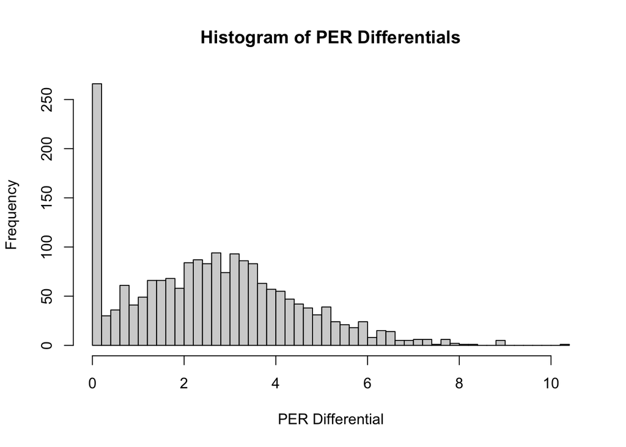

```r
hist(potential_breakout_seasons$`PER Differential`, breaks = 50, main = 'Histogram of PER Differentials', xlab = 'PER Differential', col = 'lightgray')
```

```r
breakout_seasons = potential_breakout_seasons %>% filter(PER >= 19) %>% mutate(`Previous PER` = PER - `PER Differential`)
print(breakout_seasons)
```

```
## # A tibble: 289 × 5
##    Player          Year `PER Differential`   PER `Previous PER`
##    <chr>          <dbl>              <dbl> <dbl>          <dbl>
##  1 Cliff Hagan     1958               10.4  22.6           12.2
##  2 Nikola Pekovic  2013                9    20.2           11.2
##  3 Tiny Archibald  1972                9    23             14
##  4 Bob Houbregs    1956                8.9  22             13.1
##  5 Bob Kauffman    1971                8.9  20.9           12
##  6 Dwyane Wade     2009                8.9  30.4           21.5
##  7 Len Chappell    1968                8    19             11
##  8 Bob McAdoo      1974                7.9  24.7           16.8
##  9 Jimmy Butler    2015                7.8  21.3           13.5
## 10 Jose Calderon   2007                7.7  19.1           11.4
## # … with 279 more rows
```

```r
# must account for the potential season jump
breakout_seasons %>% filter(Year >= 2000)
```

```
## # A tibble: 126 × 5
##    Player                 Year `PER Differential`   PER `Previous PER`
##    <chr>                 <dbl>              <dbl> <dbl>          <dbl>
##  1 Nikola Pekovic         2013                9    20.2           11.2
##  2 Dwyane Wade            2009                8.9  30.4           21.5
##  3 Jimmy Butler           2015                7.8  21.3           13.5
##  4 Jose Calderon          2007                7.7  19.1           11.4
##  5 LeBron James           2005                7.4  25.7           18.3
##  6 Giannis Antetokounmpo  2017                7.3  26.1           18.8
##  7 Gerald Wallace         2006                7.2  21.3           14.1
##  8 DeMarcus Cousins       2012                7.1  21.7           14.6
##  9 Amar e Stoudemire      2005                6.8  26.6           19.8
## 10 Klay Thompson          2015                6.5  20.8           14.3
## # … with 116 more rows
```